# Air Quality Exploration File

Eastern Shore Data

Marisa Lemma

7/21/2021

## Data Source

Source: Replication Data for “Disparities in PM<sub>2.5</sub> air pollution in the United States”

- Download URL: https://dataverse.lib.virginia.edu/dataset.xhtml?persistentId=doi:10.18130/V3/QLBNQJ
  - Article and Findings: https://science-sciencemag-org.proxy01.its.virginia.edu/content/369/6503/575
- Additional Information: https://science-sciencemag-org.proxy01.its.virginia.edu/content/sci/suppl/2020/07/29/369.6503.575.DC1/aaz9353_Colmer_SM.pdf

## About the Data

These data show air pollution at each census tract. They specifically focus on concentrations of PM<sub>2.5</sub>, meaning fine particulate matter that is less than 2.5 micrometers in diameter. PM<sub>2.5</sub> concentrations are measured by the number of micrograms per cubic meter. High concentrations of PM<sub>2.5</sub> indicate higher levels of air pollution.

The data show PM<sub>2.5</sub> concentrations at every year from 1981-2016. However, we focus only on 1981 and 2016 and how the data changed from 1981 to 2016.

## Variable Descriptions

```r
glimpse(airquality)
```

```
## Rows: 13
## Columns: 9
## $ trtid10         <dbl> 51001090100, 51001090200, 51001090300, 51001090400, 51…
## $ pm2_5_1981      <dbl> 26.77386475, 24.42783718, 22.57831345, 24.04582793, 24…
## $ pm2_5_2016      <dbl> 7.48875570, 6.80640209, 6.30156902, 6.75955778, 6.9702…
## $ percentile_1981 <dbl> 74.2001163, 63.6194908, 54.9364248, 61.8036511, 65.381…
## $ percentile_2016 <dbl> 60.3382365, 46.8669492, 40.0939084, 46.0843791, 49.671…
## $ STATEFP00       <dbl> 51, 51, 51, 51, 51, 51, 51, 51, 51, 51, 51, 51, 51
## $ COUNTYFP00      <chr> "001", "001", "001", "001", "001", "001", "001", "001"…
## $ PM_change       <dbl> -19.28510904, -17.62143509, -16.27674442, -17.28627014…
## $ pctile_change   <dbl> -13.86187983, -16.75254162, -14.84251641, -15.71927200…
```

Observations are census tract estimates of:

- PM<sub>2.5</sub> levels in 1981 and 2016 (`pm2_5_1981` and `pm2_5_2016`)
- Percentile rankings in 1981 and 2016 (`percentile_1981` and `percentile_2016`)
  - Percentile rankings were calculated for the whole country and were not altered once the data were filtered to just the Eastern Shore region.
- Change in PM<sub>2.5</sub> level between 1981 and 2016 (`PM_change`)
- Change in percentile rank between 1981 and 2016 (`pctile_change`)

## Summaries

Five-number summaries of all variables:

```r
airquality %>% select(-c(trtid10, STATEFP00, COUNTYFP00)) %>%
  select(where(~is.numeric(.x) && !is.na(.x))) %>%
  as.data.frame() %>%
  stargazer(., type = "text", title = "Summary Statistics", digits = 0,
            summary.stat = c("mean", "sd", "min", "median", "max"))
```

```
##
## Summary Statistics
## ============================================
## Statistic       Mean St. Dev. Min Median Max
## --------------------------------------------
## pm2_5_1981       20     9      0    23   27
## pm2_5_2016       6      2      0    6     7
## percentile_1981  49     23     0    57   74
## percentile_2016  37     18     0    42   60
## PM_change       -14     6     -19  -17   -0
## pctile_change   -11     6     -17  -14   -0
## --------------------------------------------
```

## Visual Distributions

Visual representations of the data:

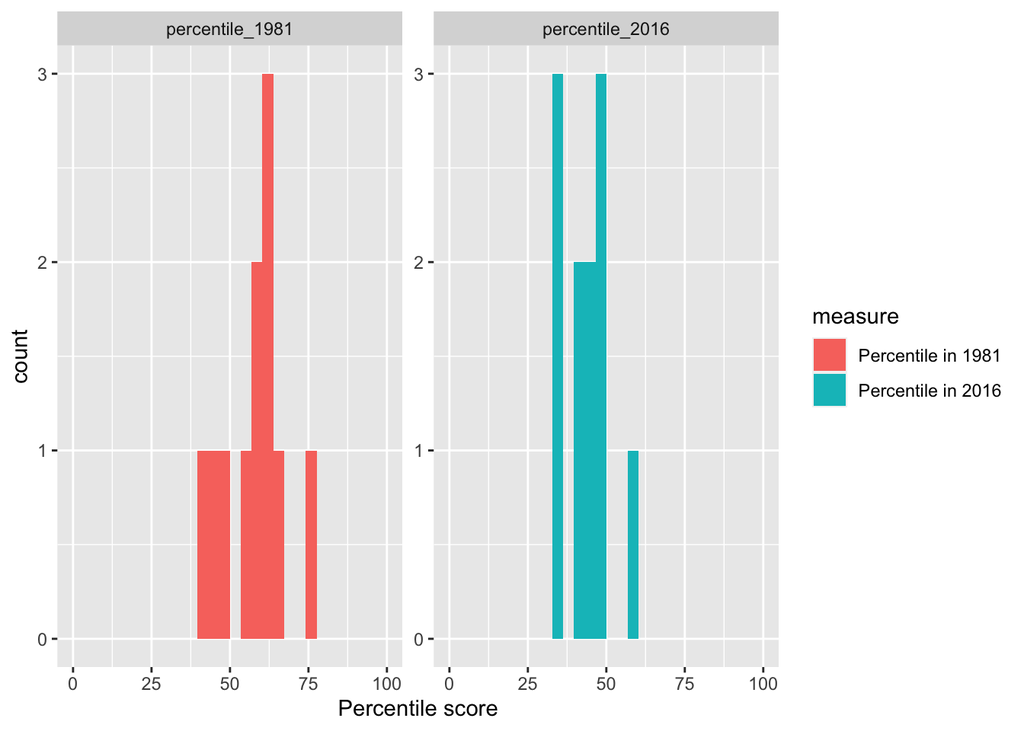

```r
airquality %>% select(trtid10, percentile_1981, percentile_2016) %>%
  pivot_longer(-trtid10, names_to = "measure", values_to = "value") %>%
  ggplot(aes(x = value, fill = measure)) +
  geom_histogram() +
  facet_wrap(~measure, scales = "free") +
  xlim(0,100) +
  xlab("Percentile score") +
  scale_fill_discrete(labels = c("Percentile in 1981", "Percentile in 2016"))
```

```r
meta %>%
  filter(varname %in% c("percentile_1981", "percentile_2016")) %>%
  mutate(label = paste0(varname, ": ", about)) %>%
  select(label) %>%
  as.list()
```

```
## $label
## [1] "percentile_1981: Nationwide percentile rank in 1981, on a scale of 0-100"
## [2] "percentile_2016: Nationwide percentile rank in 2016, on a scale of 0-100"
```

### Percentile in 1981 vs. percentile in 2016

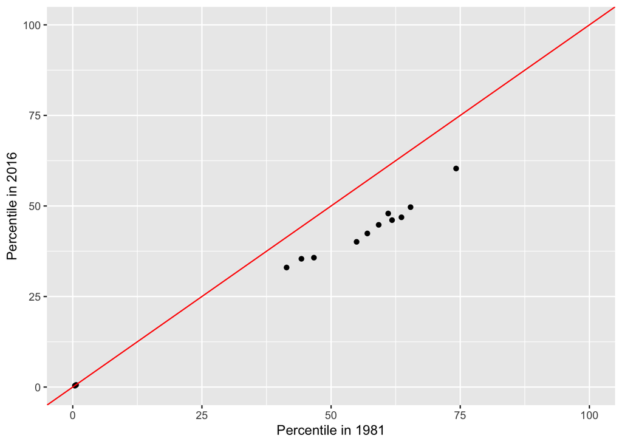

```r
airquality %>%
  ggplot() +
  geom_point(aes(x=percentile_1981, y=percentile_2016)) +
  xlim(0, 100) +
  ylim(0, 100) +
  geom_abline(intercept = 0, slope = 1, color = "red") +
  xlab("Percentile in 1981") +
  ylab("Percentile in 2016")
```

```r
meta %>%
  filter(varname %in% c("percentile_1981", "percentile_2016")) %>%
  mutate(label = paste0(varname, ": ", about)) %>%
  select(label) %>%
  as.list()
```

```
## $label
## [1] "percentile_1981: Nationwide percentile rank in 1981, on a scale of 0-100"
## [2] "percentile_2016: Nationwide percentile rank in 2016, on a scale of 0-100"
```

This scatterplot shows the relationship between a census tract’s percentile rank in 1981 and its percentile rank in 2016. The red line shows where the data would be if their percentiles in 1981 and 2016 were the same.

### Percentiles vs. percentile change

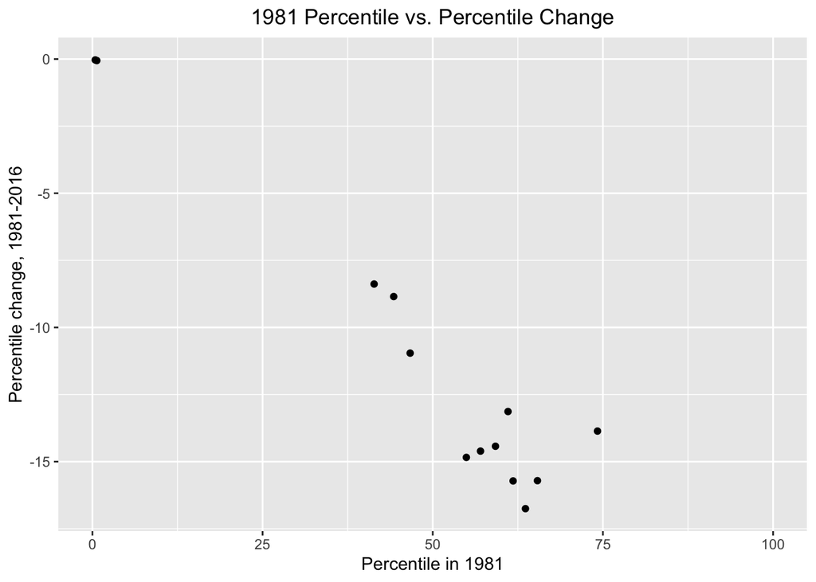

```r
airquality %>%
  ggplot() +
  geom_point(aes(x=percentile_1981, y=pctile_change)) +
  xlim(0, 100) +
  xlab("Percentile in 1981") +
  ylab("Percentile change, 1981-2016") +
  ggtitle("1981 Percentile vs. Percentile Change") +
  theme(plot.title = element_text(hjust = 0.5))
```

```r
meta %>%
  filter(varname %in% c("percentile_1981", "pctile_change")) %>%
  mutate(label = paste0(varname, ": ", about)) %>%
  select(label) %>%
  as.list()
```

```
## $label
## [1] "percentile_1981: Nationwide percentile rank in 1981, on a scale of 0-100"
## [2] "pctile_change: Change in percentile rank from 1981 to 2016 (percentile_2016 - percentile_1981)"
```

This scatterplot shows the relationship between a census tract’s percentile in 1981 and its change in percentile from 1981 to 2016.

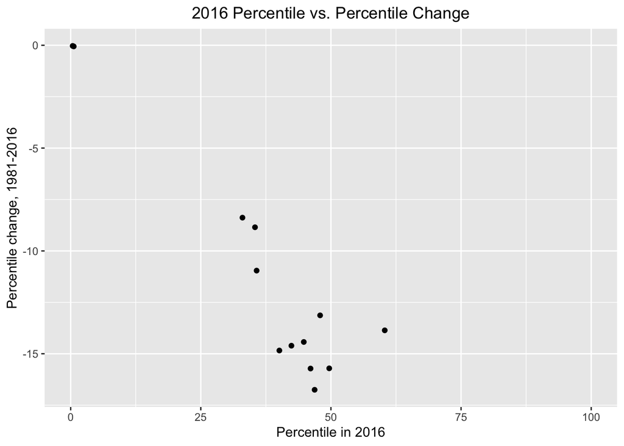

```r
airquality %>%
  ggplot() +
  geom_point(aes(x=percentile_2016, y=pctile_change)) +
  xlim(0, 100) +
  xlab("Percentile in 2016") +
  ylab("Percentile change, 1981-2016") +
  ggtitle("2016 Percentile vs. Percentile Change") +
  theme(plot.title = element_text(hjust = 0.5))
```

```r
meta %>%
  filter(varname %in% c("percentile_2016", "pctile_change")) %>%
  mutate(label = paste0(varname, ": ", about)) %>%
  select(label) %>%
  as.list()
```

```
## $label
## [1] "percentile_2016: Nationwide percentile rank in 2016, on a scale of 0-100"
## [2] "pctile_change: Change in percentile rank from 1981 to 2016 (percentile_2016 - percentile_1981)"
```

This scatterplot shows the relationship between a census tract’s percentile in 2016 and its change in percentile from 1981 to 2016.

## Spatial Distributions

### Percentile in 1981

```r
pal <- colorNumeric("Blues", reverse = FALSE, domain = easternshapes$percentile_1981)
leaflet(easternshapes) %>%
  addProviderTiles("CartoDB.Positron") %>%
  addPolygons(data = easternshapes,
              fillColor = ~pal(percentile_1981),
              weight = 1,
              opacity = 1,
              color = "white",
              fillOpacity = 0.6,
              highlight = highlightOptions(weight = 2, fillOpacity = 0.8, bringToFront = T),
              popup = paste0("Tract Number: ", easternshapes$GEOID, "<br>",
                             "Percentile: ", round(easternshapes$percentile_1981, 2))) %>%
  addLegend("bottomright", pal = pal, values = easternshapes$percentile_1981,
            title = "Percentile, 1981", opacity = 0.7)
```

[interactive chart not shown]

```r
meta %>%
  filter(varname=="percentile_1981") %>%
  mutate(label = paste0(varname, ": ", about)) %>%
  select(label) %>%
  as.list()
```

```
## $label
## [1] "percentile_1981: Nationwide percentile rank in 1981, on a scale of 0-100"
```

### Percentile in 2016

```r
pal <- colorNumeric("Blues", reverse = FALSE, domain = easternshapes$percentile_2016)
leaflet(easternshapes) %>%
  addProviderTiles("CartoDB.Positron") %>%
  addPolygons(data = easternshapes,
              fillColor = ~pal(percentile_2016),
              weight = 1,
              opacity = 1,
              color = "white",
              fillOpacity = 0.6,
              highlight = highlightOptions(weight = 2, fillOpacity = 0.8, bringToFront = T),
              popup = paste0("Tract Number: ", easternshapes$GEOID, "<br>",
                             "Percentile: ", round(easternshapes$percentile_2016, 2))) %>%
  addLegend("bottomright", pal = pal, values = easternshapes$percentile_2016,
            title = "Percentile, 2016", opacity = 0.7)
```

[interactive chart not shown]

```r
meta %>%
  filter(varname=="percentile_2016") %>%
  mutate(label = paste0(varname, ": ", about)) %>%
  select(label) %>%
  as.list()
```

```
## $label
## [1] "percentile_2016: Nationwide percentile rank in 2016, on a scale of 0-100"
```

### Percentile Change, 1981-2016

```r
pal <- colorNumeric("Blues", reverse = TRUE, domain = easternshapes$pctile_change)
leaflet(easternshapes) %>%
  addProviderTiles("CartoDB.Positron") %>%
  addPolygons(data = easternshapes,
              fillColor = ~pal(pctile_change),
              weight = 1,
              opacity = 1,
              color = "white",
              fillOpacity = 0.6,
              highlight = highlightOptions(weight = 2, fillOpacity = 0.8, bringToFront = T),
              popup = paste0("Tract Number: ", easternshapes$GEOID, "<br>",
                             "Percentile Change: ", round(easternshapes$pctile_change, 2))) %>%
  addLegend("bottomright", pal = pal, values = easternshapes$pctile_change,
            title = "Percentile Change, 1981-2016", opacity = 0.7)
```

[interactive chart not shown]

```r
meta %>%
  filter(varname=="pctile_change") %>%
  mutate(label = paste0(varname, ": ", about)) %>%
  select(label) %>%
  as.list()
```

```
## $label
## [1] "pctile_change: Change in percentile rank from 1981 to 2016 (percentile_2016 - percentile_1981)"
```

### PM<sub>2.5</sub> Concentration in 2016

```r
pal <- colorNumeric("Blues", reverse = FALSE, domain = easternshapes$pm2_5_2016)
leaflet(easternshapes) %>%
  addProviderTiles("CartoDB.Positron") %>%
  addPolygons(data = easternshapes,
              fillColor = ~pal(pm2_5_2016),
              weight = 1,
              opacity = 1,
              color = "white",
              fillOpacity = 0.6,
              highlight = highlightOptions(weight = 2, fillOpacity = 0.8, bringToFront = T),
              popup = paste0("Tract Number: ", easternshapes$GEOID, "<br>",
                             "Concentration: ", easternshapes$pm2_5_2016)) %>%
  addLegend("bottomright", pal = pal, values = easternshapes$pm2_5_2016,
            title = "PM2.5 Concentration, 2016", opacity = 0.7)
```

[interactive chart not shown]

```r
meta %>%
  filter(varname=="pm2_5_2016") %>%
  mutate(label = paste0(varname, ": ", about)) %>%
  select(label) %>%
  as.list()
```

```
## $label
## [1] "pm2_5_2016: Concentration of PM2.5 in 2016"
```

### Change in PM<sub>2.5</sub>, 1981-2016

```r
pal <- colorNumeric("Blues", reverse = TRUE, domain = easternshapes$PM_change)
leaflet(easternshapes) %>%
  addProviderTiles("CartoDB.Positron") %>%
  addPolygons(data = easternshapes,
              fillColor = ~pal(PM_change),
              weight = 1,
              opacity = 1,
              color = "white",
              fillOpacity = 0.6,
              highlight = highlightOptions(weight = 2, fillOpacity = 0.8, bringToFront = T),
              popup = paste0("Tract Number: ", easternshapes$GEOID, "<br>",
                             "PM2.5 Change: ", round(easternshapes$PM_change, 2))) %>%
  addLegend("bottomright", pal = pal, values = easternshapes$PM_change,
            title = "Change in PM2.5, 1981-2016", opacity = 0.7)
```

[interactive chart not shown]

```r
meta %>%
  filter(varname=="PM_change") %>%
  mutate(label = paste0(varname, ": ", about)) %>%
  select(label) %>%
  as.list()
```

```
## $label
## [1] "PM_change: Change in the concentration of PM2.5 from 1981 to 2016 (pm2_5_2016 - pm2_5_1981)"
```

## Important Notes

The original data uses 2000 census tracts, since that is roughly the midpoint of their 1981-2016 time frame. Since we want to be able to look at this in relation to other tract-level data, we needed this in 2010 census tracts. To estimate the data for 2010 census tracts, I used the bridging data found [here](https://s4.ad.brown.edu/Projects/Diversity/Researcher/Bridging.htm).

Since the conversion to 2010 census tracts involved some estimation, the PM<sub>2.5</sub> levels in the data may not be as accurate as the original 2000 data.